# AW Fisher tutorial

Zhiguang Huo (Department of Biostatistics, University of Florida)

2020-02-08

# 1 Introduction

## 1.1 Background

Meta-analysis aims to combine summary statistics (e.g., effect sizes, p-values) from multiple clinical or genomic studies in order to enhance statistical power. Another appealing feature of meta-analysis is that batch effect (non-biological differences between studies because of sample platforms and experimental protocols) can be avoided, because the summary statistics are usually considered as standardized. The adaptively weighted Fisher’s method (AW-Fisher) is an effective approach to combine $p$-values from $K$ independent studies and to provide better biological interpretability by characterizing which studies contribute to the meta-analysis.

## 1.2 Statistical method

Denote $\theta_k$ is the effect size of study $k$, $1\le k \le K$). The AW-Fisher’s method targets on biomarkers differentially expressed in one or more studies. The null hypothesis $H_0$ and the alternative hypothesis are listed below.
$$H_0: \vec{\boldsymbol{\theta}}\in \bigcap \{ \theta_k=0 \}$$
$$H_A: \vec{\boldsymbol{\theta}}\in \bigcup \{ \theta_k \ne 0 \},$$

Define $T(\vec{\textbf{P}}; \vec{\textbf{w}} ) = -2 \sum_{k=1}^K w_k \log P_k$, where $\vec{\textbf{w}} = (w_1, \ldots, w_K) \in {\{ 0,1 \} }^K$ is the AW weight associated with $K$ studies and $\vec{\textbf{P}} = (P_1, \ldots, P_K) \in {(0,1)}^K$ is the random variable of input $p$-value vector for $K$ studies. The AW-Fisher’s method will find the optimal weight $\vec{\textbf{w}}^*$, and calculate the test statistics and AW-Fisher p-value based on $\vec{\textbf{w}}^*$.

Collectively, the AW-Fisher’s method will provide knowledge about which study contributes to the meta-analysis result via $\vec{\textbf{w}}^*$, and also generate p-value for rejecting the null hypothesis $H_0$.

## 1.3 About this tutorial

This is a tutorial for the usage of the AWFisher package. A real data example of the multiple-tissue mouse metabolism data is used. The major contents of this tutorial includes:

- How to prepare the input for AWFisher.
- Transcriptomic meta analysis.
- Meta-analysis differential expression pattern (meta-pattern) detection.

# 2 About the package

## 2.1 How to install the package

To install this package, start R (version “3.6”) and enter:

```r
if (!requireNamespace("BiocManager", quietly = TRUE))
    install.packages("BiocManager")

BiocManager::install("AWFisher")
```

## 2.2 How to cite the package

- Huo, Z., Tang, S., Park, Y. and Tseng, G., 2020. P-value evaluation, variability index and biomarker categorization for adaptively weighted Fisher’s meta-analysis method in omics applications. *Bioinformatics*, 36(2), pp.524-532.
- The manuscript can be found here: https://www.ncbi.nlm.nih.gov/pubmed/31359040

## 2.3 Maintainer

Zhiguang Huo (zhuo@ufl.edu)

## 2.4 Description about the example data – multi-tissue mouse metabolism transcriptomic data

The purpose of the multi-tissue mouse metabolism transcriptomic data is to study how the gene expression changes with respect to the energy deficiency using mouse models. Very long-chain acyl-CoA dehydrogenase (VLCAD) deficiency was found to be associated with energy metabolism disorder in children. Two genotypes of the mouse model - wild type (VLCAD +/+) and VLCAD-deficient (VLCAD -/-) - were studied for three types of tissues (brown fat, liver, heart) with 3 to 4 mice in each genotype group. The sample size information is available in the table below. A total of 6,883 genes are available in this example dataset.

[output not shown]

## 2.5 Read in the example data

```r
library(AWFisher) # Include the AWFisher package

# load the data
data(data_mouseMetabolism)

# Verify gene names match across three tissues
all(rownames(data_mouseMetabolism$brown) == rownames(data_mouseMetabolism$heart))
```

```
#> [1] TRUE
```

```r
all(rownames(data_mouseMetabolism$brown) == rownames(data_mouseMetabolism$liver))
```

```
#> [1] TRUE
```

```r
dataExp <- data_mouseMetabolism

# Check the dimension of the three studies
sapply(dataExp, dim)
```

```
#>      brown heart liver
#> [1,]  6883  6883  6883
#> [2,]     8     7     8
```

```r
# Check the head of the three studies
sapply(dataExp, function(x) head(x,n=2))
```

```
#> $brown
#>              b.wt   b.wt.1    b.wt.2   b.wt.3   b.LCAD b.LCAD.1 b.LCAD.2
#> Copg1    8.086841 8.047482  8.140015 8.010229 8.206645 8.151032 7.956093
#> Atp6v0d1 9.807054 9.637094 10.044481 9.825333 9.868880 9.667059 9.541244
#>          b.LCAD.3
#> Copg1    8.086200
#> Atp6v0d1 9.581028
#>
#> $heart
#>              h.wt   h.wt.1   h.wt.2   h.LCAD h.LCAD.1 h.LCAD.2 h.LCAD.3
#> Copg1    7.859429 7.955171 8.045601 8.145281 8.016827 7.961778 7.964703
#> Atp6v0d1 9.479398 9.499617 9.571348 9.469063 9.516679 9.437079 9.559526
#>
#> $liver
#>              l.wt   l.wt.1    l.wt.2    l.wt.3    l.LCAD  l.LCAD.1
#> Copg1    8.501327 8.698994  8.095882  8.519093  8.539002  8.305171
#> Atp6v0d1 9.969806 9.975494 10.000650 10.161694 10.051711 10.084761
#>          l.LCAD.2  l.LCAD.3
#> Copg1    8.588183  8.554201
#> Atp6v0d1 9.989209 10.035293
```

```r
# Before performing differential expression analysis for each of these three tissues.
# Create an empty matrix to store p-value.
# Each row represents a gene and each column represent a study/tissue.

pmatrix <- matrix(0,nrow=nrow(dataExp[[1]]),ncol=length(dataExp))
rownames(pmatrix) <- rownames(dataExp[[1]])
colnames(pmatrix) <- names(dataExp)
```

## 2.6 Prepare the input p-value matrix – perform differential expression analysis in each study

```r
library(limma) # Include the limma package to perform differential expression analyses for the microarray data

for(s in 1:length(dataExp)){
  adata <- dataExp[[s]]
  ControlLabel = grep('wt',colnames(adata))
  caseLabel = grep('LCAD',colnames(adata))
  label <- rep(NA, ncol(adata))
  label[ControlLabel] = 0
  label[caseLabel] = 1

  design = model.matrix(~label)  # design matrix
  fit <- lmFit(adata,design)  # fit limma model
  fit <- eBayes(fit)

  pmatrix[,s] <- fit$p.value[,2]
}

head(pmatrix, n=2) ## look at the head of the p-value matrix
```

```
#>              brown     heart     liver
#> Copg1    0.7148393 0.3554053 0.7586203
#> Atp6v0d1 0.1584368 0.7154922 0.8502931
```

# 3 Perform AW Fisher meta analysis using the multi-tissue mouse metabolism transcriptomic data

```r
res <- AWFisher_pvalue(pmatrix) ## Perform AW Fisehr meta analysis
qvalue <- p.adjust(res$pvalue, "BH") ## Perform BH correction to control for multiple comparison.
sum(qvalue < 0.05) ## Differentially expressed genes with FDR 5%
```

```
#> [1] 755
```

```r
head(res$weights) ## Show the AW weight of the first few genes
```

```
#>      [,1] [,2] [,3]
#> [1,]    0    1    0
#> [2,]    1    0    0
#> [3,]    1    0    1
#> [4,]    1    1    0
#> [5,]    1    1    1
#> [6,]    0    0    1
```

# 4 Differential expression pattern (meta-pattern) detection.

## 4.1 Calculate dissimilarity matrix

```r
## prepare the data to feed function biomarkerCategorization
studies <- NULL
for(s in 1:length(dataExp)){
  adata <- dataExp[[s]]
  ControlLabel = grep('wt',colnames(adata))
  caseLabel = grep('LCAD',colnames(adata))
  label <- rep(NA, ncol(adata))
  label[ControlLabel] = 0
  label[caseLabel] = 1

  studies[[s]] <- list(data=adata, label=label)
}

## See help file about about how to use function biomarkerCategorization.
## Set B = 1,000 (at least) for real data application
## You may need to wrap up a function (i.e., function_limma)
## to perform differential expression analysis for each study.

set.seed(15213)
result <- biomarkerCategorization(studies,function_limma,B=100,DEindex=NULL)
```

```
#> generate DE index since it is NULL
#> based on AW fdr  0.05
#> calculating permutated score, b = 1,2,..., B (= 100)  [one "." per sample]:
#> .................................................. 50
#> ...........................
#> Warning: Zero sample variances detected, have been offset away from zero
#> ....................... 100
#>
#>  calculating variability index
```

```r
sum(result$DEindex) ## print out DE index at FDR 5%
```

```
#> [1] 755
```

```r
head(result$varibility, n=2) ## print out the head of variability index
```

```
#>        [,1]   [,2]   [,3]
#> [1,] 0.7884 0.9424 0.9600
#> [2,] 0.6864 0.6400 0.7296
```

```r
print(result$dissimilarity[1:4,1:4]) ## print out the dissimilarity matrix
```

```
#>         Psph Trappc4 Atg5 Cox18
#> Psph    1.00    0.00 0.01     0
#> Trappc4 0.00    1.00 0.75     0
#> Atg5    0.01    0.75 1.00     0
#> Cox18   0.00    0.00 0.00     1
```

## 4.2 Apply the tight clustering algorithm to get gene modules with unique meta-pattern

```r
library(tightClust) ## load tightClust package

tightClustResult <- tight.clust(result$dissimilarity, target=4, k.min=15, random.seed=15213)
```

```
#> Number of points: 755    Dimension: 755
#>
#> Looking for tight cluster 1 ...
#> k = 15
#> k = 16
#> 1 tight cluster(s) found!
#> Cluster size: 85     Remaining number of points: 670
#>
#> Looking for tight cluster 2 ...
#> k = 14
#> k = 15
#> 2 tight cluster(s) found!
#> Cluster size: 66     Remaining number of points: 604
#>
#> Looking for tight cluster 3 ...
#> k = 13
#> k = 14
#> 3 tight cluster(s) found!
#> Cluster size: 65     Remaining number of points: 539
#>
#> Looking for tight cluster 4 ...
#> k = 12
#> k = 13
#> 4 tight cluster(s) found!
#> Cluster size: 64     Remaining number of points: 475
```

```r
clusterMembership <- tightClustResult$cluster
```

## 4.3 Visualize the heatmap of the first meta-pattern module for all three tissues.

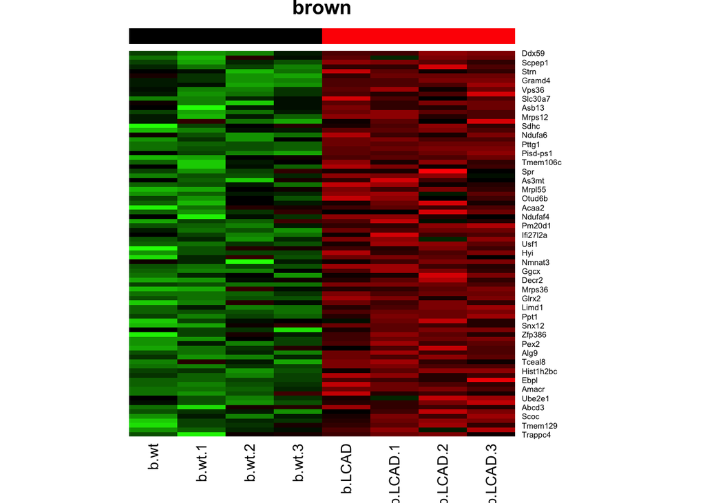

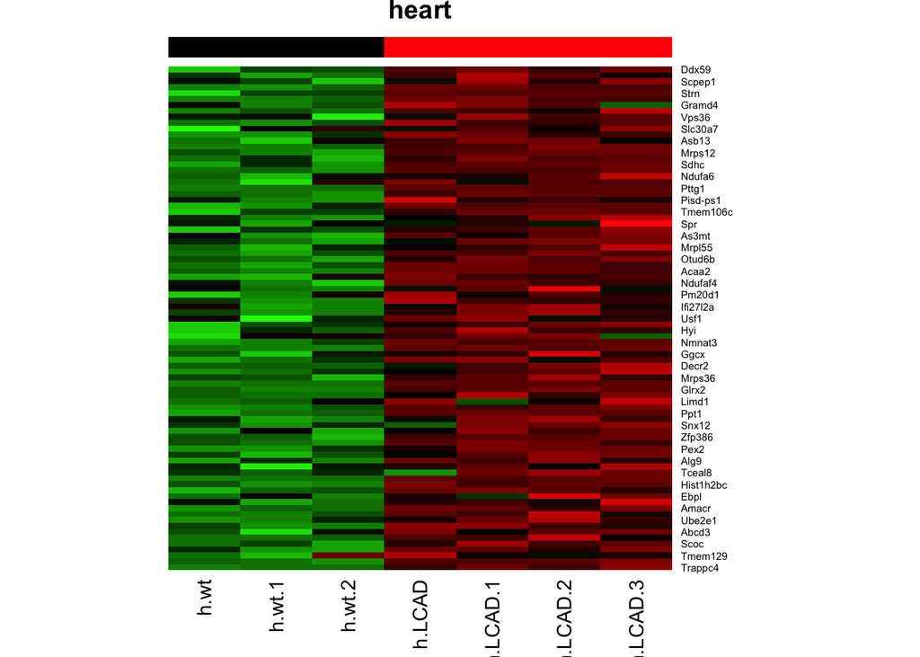

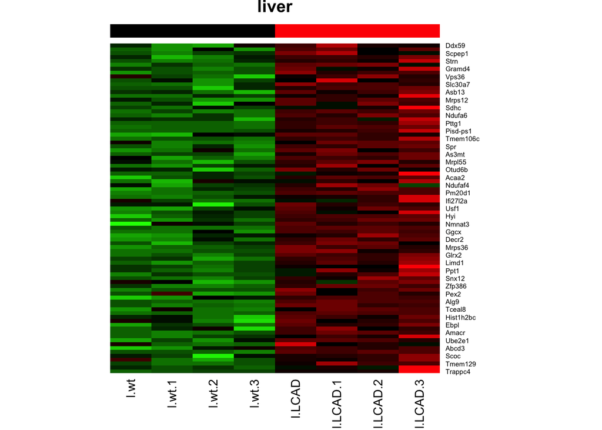

```r
for(s in 1:length(dataExp)){
  adata <- dataExp[[s]]
  aname <- names(dataExp)[s]
  bdata <- adata[qvalue<0.05, ][tightClustResult$cluster == 1 ,]
  cdata <- as.matrix(bdata)
  ddata <- t(scale(t(cdata))) # standardize the data such that for each gene, the mean is 0 and sd is 1.

  ColSideColors <- rep("black", ncol(adata))
  ColSideColors[grep('LCAD',colnames(adata))] <- "red"

  B <- 16
  redGreenColor <- rgb(c(rep(0, B), (0:B)/B), c((B:0)/16, rep(0, B)), rep(0, 2*B+1))
  heatmap(ddata,Rowv=NA,ColSideColors=ColSideColors,col= redGreenColor ,scale='none',Colv=NA, main=aname)
}
```